# Shiny - Dashboards

05/02/2018

## Passo a passo de uma análise estatística/dados.

1. Planejamento da análise
2. Coleta e/ou mineração dos dados
3. Análise descritiva
4. Análise inferencial/modelagem
5. Apresentação.

## Pacotes uteis:

```r
# library(shiny) #Shiny - indispensável
# library(DT) #Tabelas bonitas e interativas - opcional
# library(plotly) #Gráficos bonitos e interativos - opcional
# library(shinydashboard) #Deixa seu shiny estiloso - opcional
```

## O que é o Shiny?

Shiny é um pacote do R que torna fácil a construção de uma aplicação interativa via web.

Através do shiny é possível criar dashboards que facilitam a comunicação e apresentações de uma análise de dados.

## Tutorial completo do RStudio sobre Shiny.

[Tutorial](https://shiny.rstudio.com/tutorial/)

## O que é o Shiny?

[figure not shown]

## Exemplo de aplicação Shiny:

[Exemplo](https://shiny.rstudio.com/gallery/)

## Construindo uma aplicação

## Template

1. Usar o template:

[figure not shown]

## Template

- *Ui.R* - Constrói a User Inteface, isto é, a **arquitetura** da página.
- *Server.R* - Constrói as reações, interações, dinamismo.

## Exemplo 1:

No R

## Inputs e Outputs

**Inputs** são widgets que possibilitam a interação do usuário com o App.

**Outputs** é a resposta que o app dará às ações exercidas pelo usuário através do **input**

## Funções inputs:

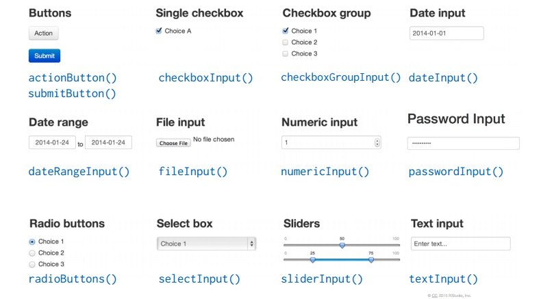

## Sintaxes:

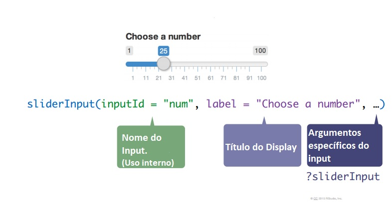

## Funções Outputs:

[figure not shown]

## Sintaxe:

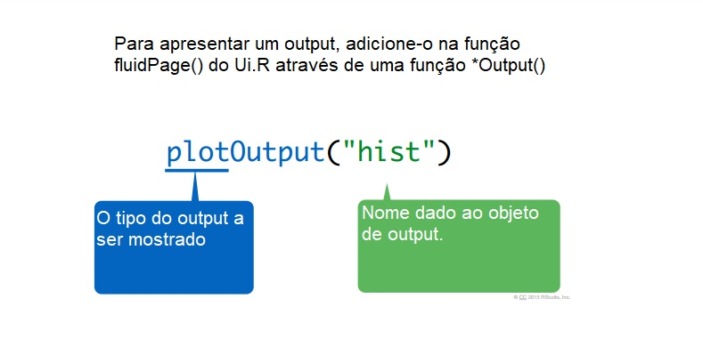

## Recaptulando:

[figure not shown]

## Exemplo 2:

No R

## Server.R

Para a construção do Server.R são necessárias apenas 3 regras:

## Server.R

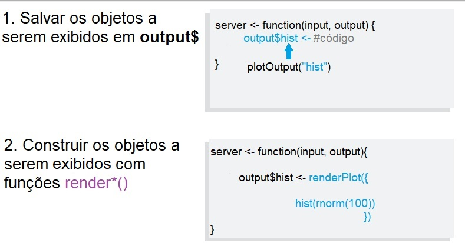

## Server.R

[figure not shown]

## Server.R

[figure not shown]

## Server.R

[figure not shown]

## Server.R

[figure not shown]

## Compartilhando seu app

Todo aplicativo Shiny é alimentado por um computador rodando R.

[figure not shown]

## Compartilhando seu app

Será necessário:

1. Um diretório contendo tudo o que seu app utiliza (datasets, imagens, etc)
2. O código em R que gera seu app (Ui.R e Server.R)

## Compartilhando seu app

[figure not shown]

## Outros métodos de compartilhamento

- Servidor comum.
- Shinyapps.io
- Construa seu próprio Shiny Server.

## Exemplo 3: DT

No R

## Exemplo 4: plotly

No R

## Exercício para casa:

- Utilize o dataset **iris**
- Utilize a biblioteca ggplot2 para criação dos gráficos (estude)
1. Crie um app que tenha como *inputs* duas colunas **quaisquer** do dataset **iris** e devolva como *output* um gráfico ggplot de dispersão entre estas colunas escolhidas.
2. Crie um outro *input* que dê a opção do usuário visualizar a reta de regressão linear simples formada entre as variáveis (colunas) escolhidas. (Dica: função *geom_smooth* de ggplot2).